https://medium.com/towards-data-science/introduction-to-simulation-with-simpy-b04c2ddf1900

# Introduction to Simulation with SimPy

## Part 1: The Basics

Darío Weitz +3400K Views Engineer, Ms. Sc., Former Associate Professor at Ing. en Sist. de Inf., Fac. Reg. Rosario, Univ. Tecnol. Nacional, Argentina. Data Viz Consultant.

756 Followers

Published in Towards Data Science · 10 min read · Feb 15, 2022

### What is Simulation?

Simulation is a widely used technique for solving complex decision problems. The conceptual idea is to use computers to imitate the operations of various types of real-world systems. To this purpose, a mathematical and/or logical model of the system under study is built and experimented until sufficient knowledge is obtained to solve the previously established decision problems.

If that mathematical model is relatively simple, it is feasible to use well-established mathematical methods (probability theory, linear programming, queuing theory, forecasting methods) to obtain an exact analytical solution. However, real-world facilities or processes are becoming increasingly complex and sophisticated, making it impossible to obtain such analytical solutions. Therefore, the best solution to understand the operation of such systems is to use the technique known as simulation.

To sum up, simulation is a technique consisting of building a mathematical model of the system under study and evaluating it numerically with the idea of collecting data to estimate the information needed to solve a decision problem.

### What is a model?

A model is a **simplified but valid representation** of a real system, with the aim of replacing it for its study.

There are several classifications of models; we are particularly interested in the following:

1. Descriptive vs. Prescriptive models: the former describe relationships and provide output data of system performance; the latter determine optimal policies for the system under study.
2. Deterministic vs. Probabilistic models: in the former, all data is assumed to be known with certainty, they do not contain random components; in the latter, there are at least some random components that are described by probability distributions. They are also called stochastic models.
3. Static vs. Dynamic models: a static model is a representation of a real system at a particular time; a dynamic model evolves over time.
4. Continuous vs. Discrete models: in the former, variables change continuously with respect to time; in the latter, variables only change at separated points in time.

### What is Discrete-Event Simulation?

**Simulation models are descriptive**, but they can be deterministic or probabilistic, static or dynamic, and continuous or discrete.

**Discrete-event simulation refers to the modeling of a system in its evolution over time in which its variables change at separated points in time**. As it is usual for the systems under analysis to have certain random components, when we refer to discrete event simulation models we are talking about:

> descriptive, dynamic, discrete, and stochastic models.

The acronym DES is used to refer to the Discrete Event Simulation method. An event is defined as an instantaneous occurrence that may change the state of a system. One of the fundamental components in DES is the mechanism to advance simulated time from one value to the next one. Usually, the so-called next-event time advance is used.

Decision problems related to queuing, inventory, manufacturing, and material-handling real-world systems are among the types of application areas for simulation with DES.

### What is SimPy?

SimPy is an object-oriented, process-based, discrete-event simulation framework based on pure Python [1].

Let’s describe the terms that make up the previous definition.

According to Wikipedia: “Object-oriented programming (OOP) is a programming paradigm based on the concept of “objects”, which can contain data and code: data in the form of fields (often known as attributes or properties), and code, in the form of procedures (often known as methods). Python supports OOP in combination with imperative, procedural programming.”[2]

There are three different approaches in simulation modeling:

#### event-scheduling approach

In the event-scheduling approach, the times of future events are explicitly coded in the simulation model and are scheduled according to the next-event time advance mechanism.

#### activity scanning approach

The activity scanning approach consists of reviewing all the activities present in the simulation model in order to determine which one can be started or completed at the next simulation clock advance.

#### process interaction approach.

Finally, the process interaction approach describes the flow of individual entities through the whole system, and the code emulates the “experience” of such entities during their routes.

> SimPy uses the process interaction approach.

Discrete event simulation was previously described.

**SimPy** provides the data analyst with the following components for developing a simulation model:

- Active components: **processes** that generate entities like customers, messages, computers, or patients for queuing systems, vehicles for material-handling systems, machines, repair work for manufacturing, and supply and demand processes for inventory systems;
- Passive components: **resources** like servers, counters, emergency rooms, repairmen crews, and tunnels for limited capacity congestion points. Two other types of passive components, levels and stores, will be described in following articles;
- **Monitor** variables for collecting data for output data analysis and plotting.

### Probability and Statistic in Simulation

Since real-world systems exhibit a high level of randomness, it becomes essential to apply concepts of probability and statistics in simulation studies. In this sense, it is very important to identify the probability distribution functions that characterize the input data. No less important is the application of statistical techniques when evaluating the results provided by the simulation model.

In this first article, we will describe some of the probability distribution functions commonly used in simulation studies. Statistical techniques used for the output data analysis will be described in a later article.

A first categorization corresponds to continuous or discrete probability distribution functions.

- Continuous PD are defined by their density functions [f(x)]
- Discrete PD are defined by probability mass functions.

Both mass and density functions depend on one or more parameters.

There are three basic types of parameters: (1) shape; (2) scale; (3) location.

1. The **shape** parameter defines the basic form of the distribution.
2. The value of the **scale** parameter expands or contracts the distribution along the x-axis.
3. The **location** parameter specifies the location of the corresponding distribution relative to zero along the x-axis.

Not necessarily, each of the probability distributions must have all three parameters. Some even have more than one value for the shape parameter.

Let us describe the most common probability distributions used in discrete event simulation.

#### Uniform Distribution:

this is a continuous distribution representing a random variable for which its outcomes between a minimum value (a) and a maximum value (b) are equally likely. It assigns equal probability to all values between its minimum and maximum.

This distribution has no shape parameter (constant or flat). The scale parameter is the difference (b-a) since increasing (b-a) expands the distribution whilst decreasing the interval length contracts it. The location parameter is a since it controls the location of the distribution along the x-axis.

In simulation studies, the uniform distribution is used when the characteristics of the random variables are not well known. Of course, it is necessary to be as rigorous as possible when selecting the values of a and b.

- https://en.wikipedia.org/wiki/Continuous_uniform_distribution
- https://commons.wikimedia.org/wiki/File:Uniform_Distribution_PDF_SVG.svg

#### Normal Distribution:

this is a continuous distribution represented by a bell-shaped curve. It is the most popular probability distribution characterized by being symmetric, the mean equal to the median, and most of its density close to the mean.

The distribution has a location parameter, the mean µ, and a scale parameter, the variance σ.

In simulation studies, the normal distribution is used to represent processing times in servers, errors in specifications of machine items, or several natural phenomena (variations of several naturally occurring variables are approximately normally distributed).

- https://en.wikipedia.org/wiki/Normal_distribution

- https://commons.wikimedia.org/wiki/File:Normal_Distribution_PDF.svg

#### Exponential Distribution.

It is a continuous distribution characterized by a memoryless property: the current time has no effect on future outcomes and the time until the next event also follows the same distribution.

It is a right-skewed distribution bounded at zero with just a scale parameter and a long right tail.

In simulation studies, the exponential distribution is widely used to represent customer interarrival times in many real-world queuing systems. It is also used to represent the time between failure in machines, computers, and electronic devices in a wide variety of facilities or industries. It is customary to use it to represent the distribution of service times in queuing systems, although this assumption is seldom plausible.

- https://en.wikipedia.org/wiki/Exponential_distribution

λ is a scale parameter, and the distribution has no location or shape parameters. The mean of the distribution is 1/λ, and the variance is (1/λ)**2.

- https://commons.wikimedia.org/wiki/File:Exponential_probability_density.svg

Poisson Distribution. It is a discrete distribution widely used to model the number of events or occurrences in some predetermined unit of measure (time or space). Its basic assumptions are: occurrences are independent; there is no limit in their number; events occur at a constant rate. In a Poisson process, there is a probability of the event occurring no matter how small the unit of exposure we might consider.

In simulation studies, the Poisson distribution is used to model times of arrival of customers in queuing systems, or the number of products demanded per clients in an inventory system.

- https://en.wikipedia.org/wiki/Poisson_distribution

- https://commons.wikimedia.org/w/index.php?curid=3817954

#### Weibull Distribution:

this is a continuous distribution that can take many different forms depending on the value of its parameters.

The great utility of the Weibull distribution lies in the fact that, depending on the values taken by its parameters, it can be approximated to an exponential distribution (k = 1), very close to a normal distribution (k = 3.25), or to a Rayleigh distribution (k = 2 and λ = √2 σ).

We used the Weibull distribution in simulation studies to model failure analysis, fatigue tests, and times to complete a determined task. In this distribution, the probability of occurrence has memory (changes with time).

- https://en.wikipedia.org/wiki/Weibull_distribution

- https://commons.wikimedia.org/w/index.php?curid=9671814

### Generating Probabilistic Outcomes for Simulation Studies

To develop our discrete-event simulation study, we need first to identify the probability distribution functions that characterize the input data. Then, we need to generate sequences of numbers that imitate such distributions.

An outcome generated from a probability distribution function is named a random variate. We are talking about random numbers. In DES, we define a random number as one that is uniformly distributed between 0 and 1. We need an algorithm capable of generating such sequence of numbers; fortunately, every technical programming language has an algorithm capable of providing such a stream.

That sequence of uniformly distributed numbers between 0 and 1 are named pseudorandom numbers because they are generated with a deterministic process. The algorithms included in the libraries are extensively tested with several statistical tests until the sequence is as close as possible to a truly random stream.

In simulation studies, it is often necessary to reproduce the sequence of random numbers, particularly when seeking to compare the responses of the same system to different alternatives. The random number generator needs a number to start the sequence (a seed value). By default it uses the current system time. But, if you need to reproduce the stream, you must code something like random.seed(1234) every time you need to restart the sequence. As Scipy also uses the Numpy random generators, it is feasible to use the Numpy seed function: np.random.seed(1234).

The scipy.stats module includes over 80 continuous random variables and at least 10 discrete random variables. The method for generating random variates is rvs. The parameters of the distribution (location, shape, scale) are in a standardized form. It is important to read the corresponding documentation because, as previously indicated, the number of parameters may be different depending on the distribution.

https://docs.scipy.org/doc/scipy/reference/stats.html

```python
import numpy as np
import matplotlib.pyplot as plt
import seaborn as sns

np.random.seed(0)
```

To generate 100 floating random numbers with a uniform distribution between 1 and 6:

https://docs.scipy.org/doc/scipy/reference/generated/scipy.stats.uniform.html#scipy.stats.uniform

```
3.363969197562588
```

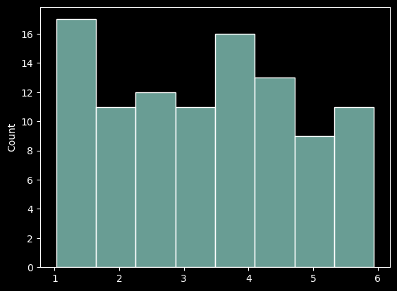

```python
from scipy.stats import uniform

r_uniform = uniform.rvs(loc=1, scale=5, size=100)
sns.histplot(r_uniform, kde=False)

print(r_uniform.mean())
plt.show()
```

To generate 100 integer random numbers with a uniform distribution between 1 and 9:

https://docs.scipy.org/doc/scipy/reference/generated/scipy.stats.randint.html#scipy.stats.randint

```
5.29
```

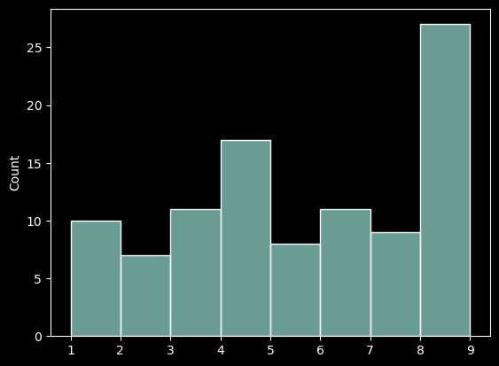

```python
from scipy.stats import randint

r_unif_di = randint.rvs(1, 10, loc=0, size=100)
sns.histplot(r_unif_di, kde=False)

print(r_unif_di.mean())
plt.show()
```

https://docs.scipy.org/doc/scipy/reference/generated/scipy.stats.norm.html#scipy.stats.norm

```
0.08501817745474126
```

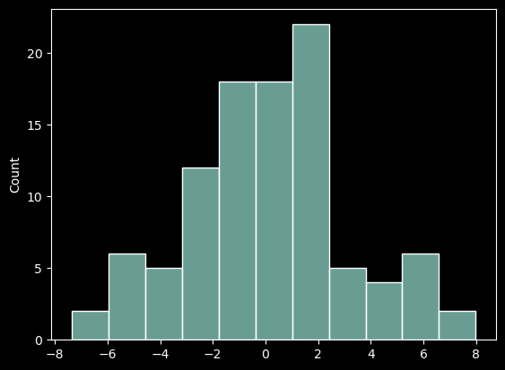

```python
from scipy.stats import norm

r_normal = norm.rvs(loc=0, scale=3, size=100)
sns.histplot(r_normal, kde=False)

print(r_normal.mean())
plt.show()
```

https://docs.scipy.org/doc/scipy/reference/generated/scipy.stats.expon.html#scipy.stats.expon

```
2.670285765981518
```

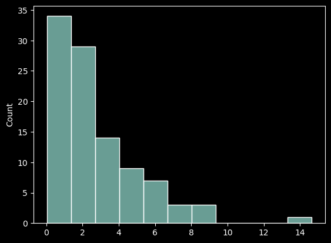

```python
from scipy.stats import expon

r_expon = expon.rvs(scale=3, size=100)
sns.histplot(r_expon, kde=False)
print(r_expon.mean())
plt.show()
```

To generate 100 integer random numbers with a Poisson distribution with a shape parameter corresponding to the mean and the variance:

https://docs.scipy.org/doc/scipy/reference/generated/scipy.stats.poisson.html#scipy.stats.poisson

```
0.57
```

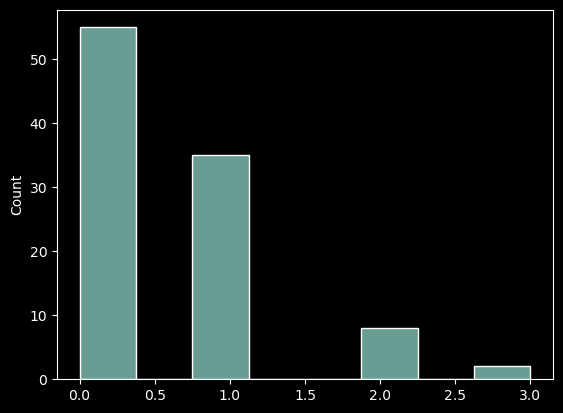

```python
from scipy.stats import poisson

r_poisson = poisson.rvs(0.6, size=100)
sns.histplot(r_poisson, kde=False)
print(r_poisson.mean())
plt.show()
```

https://docs.scipy.org/doc/scipy/reference/generated/scipy.stats.weibull_min.html#scipy.stats.weibull_min

```
1.0076410952310209
```

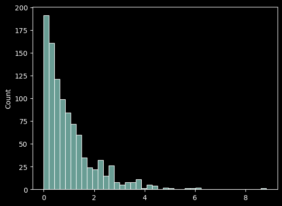

```python
from scipy.stats import weibull_min

r_weibull = weibull_min.rvs(1, size=1000)
sns.histplot(r_weibull, kde=False)
print(r_weibull.mean())
plt.show()
```

https://docs.scipy.org/doc/scipy/reference/generated/scipy.stats.gamma.html

```
1.0157004291595624
```

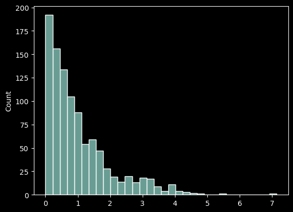

```python
from scipy.stats import gamma

r_gamma = gamma.rvs(1, size=1000)
sns.histplot(r_gamma, kde=False)
print(r_gamma.mean())
plt.show()
```